# CEE218X Homework #2

Chenbo Wang (wangcb@stanford.edu)

10/20/2020

```r
library(tidyverse)
library(sf)
library(tigris)
library(leaflet)
library(censusapi)
library(tidycensus)
library(dplyr)

# Add key to .Renviron
Sys.setenv(CENSUS_KEY="df5d39697e74ea76fdb9bea9b3a60afd0eeb0b2d")
# Reload .Renviron
readRenviron("~/.Renviron")
# Check to see that the expected key is output in your R console
Sys.getenv("CENSUS_KEY")
```

```r
census_api_key("df5d39697e74ea76fdb9bea9b3a60afd0eeb0b2d", install = TRUE, overwrite = TRUE)
pums_vars_2018 <- pums_variables %>% filter(year == 2018, survey == "acs1")
pums_vars_2018_distinct <-
  pums_vars_2018 %>%
  distinct(var_code, var_label, data_type, level)
```

```r
#acs_vars_2019_1yr <-
#  listCensusMetadata(
#    name = "2019/acs/acs1",
#    type = "variables"
#  )
#saveRDS(acs_vars_2019_1yr,"acs_vars_2019_1yr.rds")
acs_vars_2019_1yr <- readRDS("acs_vars_2019_1yr.rds")
```

## Part I

**An equity analysis of educational attainment by race. Plot the “stacked” and “filled” bar charts as demonstrated in 2.2; from there, you are welcome to add as many comments and supplementary visualizations as you’d like. Essentially, respond to the question: “Is there disproportionate education attainment by race in the County?”**

```r
census_race_labels <-
  c(
    "White Alone",
    "Black or African American",
    "American Indian and Alaska Native Alone",
    "Asian Alone",
    "Native Hawaiian and Other Pacific Islander Alone",
    "Some Other Race Alone",
    "Two or More Races"
  )
```

ACS data B15002 in 2019 was used to conduct the analysis. The B15002 data contains educational attainment for seven races for male and female. Because we do not want to differentiate between sex, we aggregate estimates for male and female.

```r
SF_education_race <-
  1:7 %>%
  map_dfr(function(x){
    getCensus(
      name = "acs/acs1",
      vintage = 2019,
      region = "county:075",
      regionin = "state:06",
      vars = paste0("group(B15002",LETTERS[x],")")
    ) %>%
      select(!c(GEO_ID,state,NAME) & !ends_with(c("EA","MA","M"))) %>%
      pivot_longer(
        ends_with("E"),
        names_to = "variable",
        values_to = "estimate"
      ) %>%
      left_join(
        acs_vars_2019_1yr %>%
          select(name, label),
        by = c("variable" = "name")
      ) %>%
      select(-variable) %>%
      separate(
        label,
        into = c(NA,NA,"sex","education"),
        sep = "!!"
      ) %>%
      filter(!is.na(education)) %>%
      mutate(race = census_race_labels[x]) %>%
      group_by(education,race) %>%
      summarize(
        estimate =
          sum(
            estimate, na.rm = T
            )
        )
  })
```

By inspect the resulting dataframe, we can see that estimates for “American Indian and Alaska Native Alone” and “Native Hawaiian and Other Pacific Islander Alone” are not available (NA), so we can remove those rows representing null values for “American Indian and Alaska Native Alone” and “Native Hawaiian and Other Pacific Islander Alone”.

```r
SF_education_race <- SF_education_race %>%
  filter(
    race %in%
      c(census_race_labels[1],census_race_labels[2],
        census_race_labels[4],census_race_labels[6],
        census_race_labels[7])
  )
```

```r
SF_race_total <-
  SF_education_race %>%
  group_by(race) %>%
  summarize(estimate = sum(estimate)) %>%
  mutate(education = "Total")
```

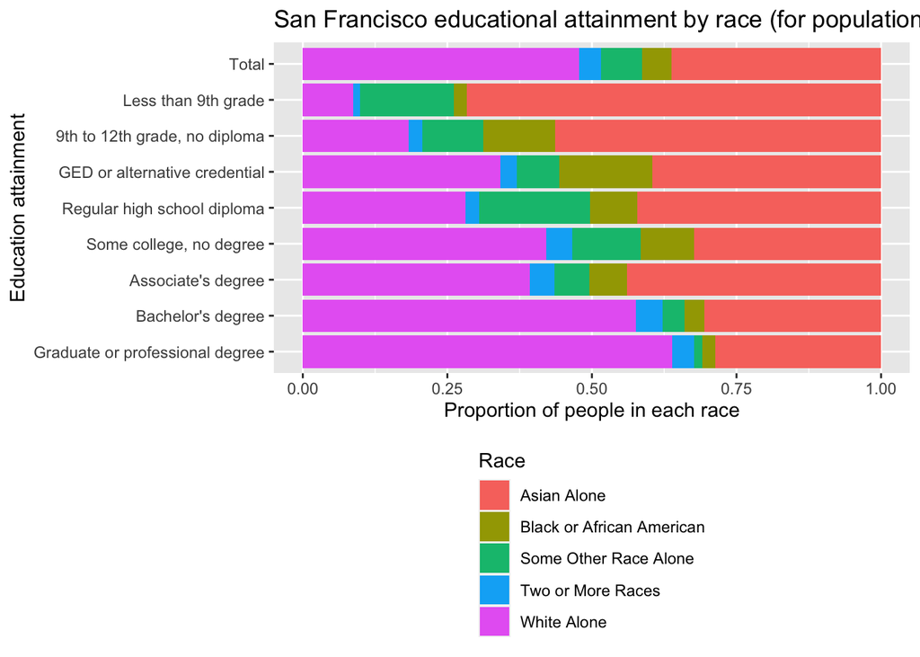

```r
education_level <- c("Less than 9th grade","9th to 12th grade, no diploma","GED or alternative credential", "Regular high school diploma","Some college, no degree","Associate's degree","Bachelor's degree", "Graduate or professional degree")
SF_education_race %>%
  rbind.data.frame(SF_race_total) %>%
  ggplot() +
  geom_bar(
    aes(
      x = education %>% factor(levels = rev(c("Total",education_level))),
      y = estimate,
      fill = race
    ),
    stat = "identity",
    position = "fill"
  ) +
  labs(
    x = "Education attainment",
    y = "Proportion of people in each race",
    title = "San Francisco educational attainment by race (for population 25 years or older)",
    fill = "Race"
  ) +
  coord_flip() +
  theme(
    legend.position = "bottom",
    legend.direction = "vertical"
  )
```

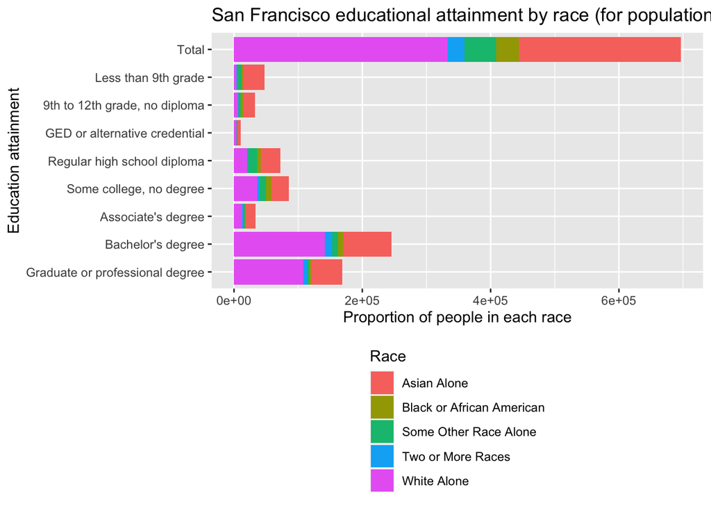

```r
education_level <- c("Less than 9th grade","9th to 12th grade, no diploma","GED or alternative credential", "Regular high school diploma","Some college, no degree","Associate's degree","Bachelor's degree", "Graduate or professional degree")
SF_education_race %>%
  rbind.data.frame(SF_race_total) %>%
  ggplot() +
  geom_bar(
    aes(
      x = education %>% factor(levels = rev(c("Total",education_level))),
      y = estimate,
      fill = race
    ),
    stat = "identity",
    position = "stack"
  ) +
  labs(
    x = "Education attainment",
    y = "Proportion of people in each race",
    title = "San Francisco educational attainment by race (for population 25 years or older)",
    fill = "Race"
  ) +
  coord_flip() +
  theme(
    legend.position = "bottom",
    legend.direction = "vertical"
  )
```

It should be noted that the ACS datasets on educational attainment only include “population 25 years or older”, which means younger population who are on their early life stages are not considered in this study. And this could be problematic depending on the analysis outcome.

If the educational attainment is indeed race-blind, we would expect the proportion of different races in each education attainments to be roughly the same as the proportion of total population in different races. But apparently it is not the case as can be seen from the plot above. If we consider “Bachelor’s degree” and “Graduate or professional degree” to be high educational attainment, the rest to be “low” educational attainment, we can clearly see that “Black or African American” and “Asian Alone” account for unproportionally low percentage in high educational attainment. For the lowest education level: “Less than 9th grade”, the “Asian Alone” and “Some Other Race Alone” have much higher take-up than their respective take-up in total population.

Considering the fact that there are a considerable number of first-generation immigrants in San Francisco (e.g., Chinatown), and it is likely that elderly immigrants had not gotten the opportunities to be educated wwhen they were young before they came to live in San Francisco. Recall that the ACS dataset only includes population of 25 years or older, the results might change to some extent if population of 18 years old to 24 years old are included in the dataset.

```r
High_White <- SF_education_race %>%
  filter(
    education %in% c("Bachelor's degree",
                     "Graduate or professional degree"))%>%
  filter(race == "White Alone") %>%
  pull(estimate) %>%
  sum()
High_ed <- SF_education_race %>%
  filter(
    education %in% c("Bachelor's degree",
                     "Graduate or professional degree"))%>%
  pull(estimate) %>%
  sum()
# Percentage of White population in High educational attainment (Bachelor's and Graduate or Professional)
((High_White/High_ed)*100) %>% round()
```

```
## [1] 60
```

```r
# Percentage of White population over 25
((SF_race_total$estimate[5]/sum(SF_race_total$estimate))*100) %>% round()
```

```
## [1] 48
```

```r
Low_Asian <- SF_education_race %>%
  filter(
    education %in% c("Less than 9th grade",
                     "9th to 12th grade, no diploma"))%>%
  filter(race == "Asian Alone") %>%
  pull(estimate) %>%
  sum()

Low_White <- SF_education_race %>%
  filter(
    education %in% c("Less than 9th grade",
                     "9th to 12th grade, no diploma"))%>%
  filter(race == "White Alone") %>%
  pull(estimate) %>%
  sum()

Low_Black <- SF_education_race %>%
  filter(
    education %in% c("Less than 9th grade",
                     "9th to 12th grade, no diploma"))%>%
  filter(race == "Black or African American") %>%
  pull(estimate) %>%
  sum()

Low_ed <- SF_education_race %>%
  filter(
    education %in% c("Less than 9th grade",
                     "9th to 12th grade, no diploma"))%>%
  pull(estimate) %>%
  sum()

# Percentage of White population in Low educational attainment ("Less than 9th grade", 9th to 12th grade, no diploma")
((Low_White/Low_ed)*100) %>% round()
```

```
## [1] 13
```

```r
# Percentage of Asian population in Low educational attainment ("Less than 9th grade", 9th to 12th grade, no diploma")
((Low_Asian/Low_ed)*100) %>% round()
```

```
## [1] 65
```

```r
# Percentage of Asian population over 25
((SF_race_total$estimate[1]/sum(SF_race_total$estimate))*100) %>% round()
```

```
## [1] 36
```

```r
# Percentage of Black population in Low educational attainment ("Less than 9th grade", 9th to 12th grade, no diploma")
((Low_Black/Low_ed)*100) %>% round()
```

```
## [1] 6
```

```r
# Percentage of Black population over 25
((SF_race_total$estimate[2]/sum(SF_race_total$estimate))*100) %>% round()
```

```
## [1] 5
```

The overall population in San Francisco is 48% White Alone, while the the subpopulation of persons with high educational attainment (Bachelor’s degree and Graduate or professional degree) is 60% White. Such discrepancy shows that on average White people are more likely to have a higher educational attainment while non-white races are less likely to. Consider the extreme opposite of high educational attainment, for the two lowest education levels: Less than 9th grade and 9th to 12th grade, no diploma, 65% of the subpopulation is Asian, while the overall Asian population in San Francisco is only 36%. Meanwhile only 13% of the subpopulation with low attainment is White even though 48% of the total population in San Francisco is White.

## Part II

An estimate of the number and percentage of K-12 students who have no internet access at home, using the latest available PUMS data. State your assumptions clearly, especially how useful the available data is for understanding the challenges of remote learning in 2020. Include a map of this metric for all PUMAs in the Bay Area.

```r
#temp <- tempfile()
#download.file("https://www2.census.gov/programs-surveys/acs/data/pums/2018/1-Year/csv_hca.zip",destfile = temp, mode = "wb")
#library(tidyverse)
#pums_hca_2018_1yr <- read_csv(unzip(temp,"psam_h06.csv"))

# unlink(temp)
# pums_hca_2018_1yr <- read_csv("psam_h06.csv")
# saveRDS(pums_hca_2018_1yr, file = "pums_hca_2018_1yr.rds")
pums_hca_2018_1yr <- readRDS("pums_hca_2018_1yr.RDS")
# install.packages("devtools")
# devtools::install_github("walkerke/tidycensus")
```

```r
bay_county_names <-
  c(
    "Alameda",
    "Contra Costa",
    "Marin",
    "Napa",
    "San Francisco",
    "San Mateo",
    "Santa Clara",
    "Solano",
    "Sonoma"
  )

ca_counties <- counties("06", cb = T, progress_bar = F)

bay_counties <-
  ca_counties %>%
  filter(NAME %in% bay_county_names)

SF_County <-
  ca_counties %>%
  filter(NAME == "San Francisco")

ca_pumas <-
  pumas("06", cb = T, progress_bar = F)

bay_pumas <-
  ca_pumas %>%
  st_centroid() %>%
  .[bay_counties, ] %>%
  st_set_geometry(NULL) %>%
  left_join(ca_pumas %>% select(GEOID10)) %>%
  st_as_sf()

SF_pumas <-
  ca_pumas %>%
  st_centroid() %>%
  .[SF_County, ] %>%
  st_set_geometry(NULL) %>%
  left_join(ca_pumas %>% select(GEOID10)) %>%
  st_as_sf()
```

```r
#ca_pums <- get_pums(
#  variables = c(
#    "PUMA",
#    "ACCESS",
#    "NRC",
#    "PWGTP",
#    "SERIALNO",
#    "SCHG"
#  ),
#  state = "06",
#  year = 2018,
#  survey = "acs5",
#  recode = T
#)
# saveRDS(ca_pums,"ca_pums.rds")
ca_pums <- readRDS("ca_pums.rds")

bay_pums <-
  ca_pums %>%
  filter(PUMA %in% bay_pumas$PUMACE10)
```

```r
SF_pums <- get_pums(
  variables = c(
    "PUMA",
    "ACCESS",
    "NRC",
    "PWGTP",
    "SERIALNO",
    "SCHG"
  ),
  state = "06",
  puma = SF_pumas$PUMACE10,
  year = 2018,
  survey = "acs1",
  recode = T
)
# saveRDS(SF_pums,"SF_pums.rds")
SF_pums <- readRDS("SF_pums.rds")
```

```r
SF_pum_filtered <-
  SF_pums %>%
  filter(WGTP != 0) %>%
  mutate(
    SCHG = as.numeric(SCHG)
  ) %>%
  filter(
    SCHG %in% c(2:14)
  ) %>%
  mutate(
    k12_student_without_internet = ifelse(
        (ACCESS == "3"),
      PWGTP,
      0
    )
  ) %>%
  mutate(
    k12_student = PWGTP
  ) %>%
  group_by(PUMA) %>%
  summarize(
    k12_student_without_internet =
      sum(k12_student_without_internet, na.rm =T),
    k12_student =
      sum(k12_student, na.rm =T)
  ) %>%
  mutate(
    perc_k12_student_without_internet = k12_student_without_internet/k12_student *100
  ) %>%
  left_join(
    SF_pumas %>%
      select(PUMACE10),
    by = c("PUMA" = "PUMACE10")
  ) %>%
  st_as_sf()

sum(SF_pum_filtered$k12_student_without_internet)
```

```
## [1] 3708
```

```r
sum(SF_pum_filtered$k12_student)
```

```
## [1] 75014
```

```r
sum(SF_pum_filtered$k12_student_without_internet)/sum(SF_pum_filtered$k12_student)
```

```
## [1] 0.04943077
```

```r
bay_pum_filtered <-
  bay_pums %>%
  filter(WGTP != 0) %>%
  filter(
    SCHG %in% c("03","04","05","06","07","08","09","10","11","12","13","14")
  ) %>%
  mutate(
    k12_student_without_internet = ifelse(
        (ACCESS == "3"),
      PWGTP,
      0
    )
  ) %>%
  mutate(
    k12_student = PWGTP
  ) %>%
  group_by(PUMA) %>%
  summarize(
    k12_student_without_internet =
      sum(k12_student_without_internet, na.rm =T),
    k12_student =
      sum(k12_student, na.rm =T)
  ) %>%
  mutate(
    perc_k12_student_without_internet = k12_student_without_internet/k12_student *100
  ) %>%
  left_join(
    bay_pumas %>%
      select(PUMACE10),
    by = c("PUMA" = "PUMACE10")
  ) %>%
  st_as_sf()
```

```r
pums_pal <- colorNumeric(
  palette = "Reds",
  domain = bay_pum_filtered$k12_student_without_internet
)

leaflet() %>%
  addTiles() %>%
  addPolygons(
    data = bay_pum_filtered,
    fillColor = ~pums_pal(k12_student_without_internet),
    color = "white",
    opacity = 0.5,
    fillOpacity = 0.5,
    weight = 1,
    label = ~paste0(
      round(k12_student_without_internet),
      "number of K-12 students without Internet access"
    ),
    highlightOptions = highlightOptions(
      weight = 2,
      opacity = 1
    )
  ) %>%
  addLegend(
    data = bay_pum_filtered,
    pal = pums_pal,
    values = ~k12_student_without_internet,
    title = "Number of K-12 students without Internet access"
  )
```

[interactive chart not shown]

```r
pums_pal <- colorNumeric(
  palette = "Reds",
  domain = bay_pum_filtered$perc_k12_student_without_internet
)

leaflet() %>%
  addTiles() %>%
  addPolygons(
    data = bay_pum_filtered,
    fillColor = ~pums_pal(perc_k12_student_without_internet),
    color = "white",
    opacity = 0.5,
    fillOpacity = 0.5,
    weight = 1,
    label = ~paste0(
      round(perc_k12_student_without_internet),
      "% K-12 students without Internet access"
    ),
    highlightOptions = highlightOptions(
      weight = 2,
      opacity = 1
    )
  ) %>%
  addLegend(
    data = bay_pum_filtered,
    pal = pums_pal,
    values = ~perc_k12_student_without_internet,
    title = "% K-12 students without Internet access"
  )
```

[interactive chart not shown]

### Comment

Overall, in San Francisco county, about 5% of k-12 students have no access to Internet according to the latest PUMS data available. To be more exact, 3708 k-12 students out of a total of 75014 k-12 students in San Francisco county have no access to Internet as of 2018. It is a potentially huge problem especially considering the ongoing remote learning due to Covid-19. It is likely that those k-12 students who have no access to Internet are also among other social groups that are vulnerable in terms of public health issues, e.g., an Internet-depreived k-12 student could just as well be from a low-income household, thus worsening the education quality. Even though the detailed analysis has not been conducted here, we could potentially break down the internet-deprived k-12 students into different socialeconomic groups (income, housing tenure, sex, ethnicity, etc.) and perfrom an equity analysis. If we do that, we could better understand the social vulnerability of the Internet-deprived k-12 students.

```r
sum(bay_pum_filtered$k12_student_without_internet)
```

```
## [1] 43166
```

```r
sum(bay_pum_filtered$k12_student)
```

```
## [1] 1065051
```

```r
sum(bay_pum_filtered$k12_student_without_internet)/sum(bay_pum_filtered$k12_student)
```

```
## [1] 0.04052951
```

When we look at the entire Bay Area, over 43,000 k-12 students have no Internet access among all 1 million k-12 students. That is, about 4% of k-12 students in the Bay Area have no access to Internet according to the latest PUMS data available. Comparing this to San Francisco county, we could see that San Francisco is above the average. As shown in both maps, several areas stand out in dark red, indicating a high percentage of Internet-deprived k-12 students.

## Part III

A migration analysis, as demonstrated in 2.3, using data on educational attainment. Discuss what you believe can be interpreted from the results of this methodology, especially as it relates to the “educational mobility” of Bay Area residents.

```r
acs_vars_2019_1yr <- readRDS("acs_vars_2019_1yr.rds")
```

```r
sf_mobility_current_19 <-
  getCensus(
    name = "acs/acs1",
    vintage = 2019,
    region = "county:075",
    regionin = "state:06",
    vars = c("group(B07009)")
  ) %>%
  select(!c(GEO_ID,state,NAME) & !ends_with(c("EA","MA","M"))) %>%
  pivot_longer(
    ends_with("E"),
    names_to = "variable",
    values_to = "estimate"
  ) %>%
  left_join(
    acs_vars_2019_1yr %>%
      select(name, label),
    by = c("variable" = "name")
  ) %>%
  select(-variable) %>%
  separate(
    label,
    into = c(NA,NA,"mobility","education"),
    sep = "!!"
  ) %>%
  filter(!is.na(education)) %>%
  mutate(
    mobility = ifelse(
      mobility %in% c("Same house 1 year ago:", "Moved within same county:"),
      "Here since last year",
      "Inflow"
    )
  ) %>%
  group_by(mobility, education) %>%
  summarize(estimate = sum(estimate))
```

```r
sf_mobility_lastyear_19 <-
  getCensus(
    name = "acs/acs1",
    vintage = 2019,
    region = "county:075",
    regionin = "state:06",
    vars = c("group(B07409)")
  ) %>%
  select(!c(GEO_ID,state,NAME) & !ends_with(c("EA","MA","M"))) %>%
  pivot_longer(
    ends_with("E"),
    names_to = "variable",
    values_to = "estimate"
  ) %>%
  left_join(
    acs_vars_2019_1yr %>%
      select(name, label),
    by = c("variable" = "name")
  ) %>%
  select(-variable) %>%
  separate(
    label,
    into = c(NA,NA,"mobility","education"),
    sep = "!!"
  ) %>%
  filter(!is.na(education)) %>%
  mutate(
    mobility = ifelse(
      mobility %in% c("Same house:", "Moved within same county:"),
      "Here since last year",
      "Outflow"
    )
  ) %>%
  group_by(mobility, education) %>%
  summarize(estimate = sum(estimate))
```

```r
sf_mobility_current_18 <-
  getCensus(
    name = "acs/acs1",
    vintage = 2018,
    region = "county:075",
    regionin = "state:06",
    vars = c("group(B07009)")
  ) %>%
  select(!c(GEO_ID,state,NAME) & !ends_with(c("EA","MA","M"))) %>%
  pivot_longer(
    ends_with("E"),
    names_to = "variable",
    values_to = "estimate"
  ) %>%
  left_join(
    acs_vars_2019_1yr %>%
      select(name, label),
    by = c("variable" = "name")
  ) %>%
  select(-variable) %>%
  separate(
    label,
    into = c(NA,NA,"mobility","education"),
    sep = "!!"
  ) %>%
  filter(!is.na(education)) %>%
  mutate(
    mobility = "Here last year"
  ) %>%
  group_by(mobility, education) %>%
  summarize(estimate = sum(estimate))
```

```r
sf_flows_19 <-
  rbind.data.frame(
    sf_mobility_current_18,
    sf_mobility_lastyear_19 %>%
      filter(mobility == "Outflow"),
    sf_mobility_current_19 %>%
      filter(mobility == "Inflow"),
    sf_mobility_current_19 %>%
      group_by(education) %>%
      summarize(estimate = sum(estimate)) %>%
      mutate(mobility = "Here this year")
  ) %>%
  pivot_wider(
    names_from = mobility,
    values_from = estimate
  ) %>%
  mutate(
    `External net` = Inflow - Outflow,
    `Internal net` = `Here this year` - `Here last year` - `External net`,
  ) %>%
  select(
    `Educational attainment` = education,
    `Internal net`,
    `External net`,
    `Here last year`,
    `Here this year`,
    Outflow,
    Inflow
  )
sf_flows_19$`Educational attainment` %>% factor(
  levels = c("Less than high school graduate","High school graduate (includes equivalency)", "Some college or associate's degree", "Bachelor's degree","Graduate or professional degree"))
```

```
## [1] Bachelor's degree
## [2] Graduate or professional degree
## [3] High school graduate (includes equivalency)
## [4] Less than high school graduate
## [5] Some college or associate's degree
## 5 Levels: Less than high school graduate ...
```

```r
sf_flows_19_ordered <- sf_flows_19[c(4,3,5,1,2),]
sf_flows_19_ordered
```

```
## # A tibble: 5 x 7
##   `Educational at… `Internal net` `External net` `Here last year`
##   <chr>                     <dbl>          <dbl>            <dbl>
## 1 Less than high …          10171          -2013            73381
## 2 High school gra…          -3363            792            85850
## 3 Some college or…            823          -2490           123004
## 4 Bachelor's degr…           -828          -6881           253594
## 5 Graduate or pro…           3938          -1435           166736
## # … with 3 more variables: `Here this year` <dbl>, Outflow <dbl>, Inflow <dbl>
```

Positive internal net means more people that have been staying in the Bay since 2018 obtain this degree in 2019, while negative internal means the opposite. Positive external net means the number of people who moves into San Francisco holding this degree is larger than the number of people leaving San Francisco holding this degree. It should be noted that this analysis only considers people over the age of 15, as the data is provided for people over age of 15.

Negative external net for both Bachelor’s and Graduate or professional degree-holders indicate that overall people with high educational attainment are “fleeing” away from San Francisco. It could be due to that San Francisco is not so attractive to people with higher degrees with everlasting wildfire, or that San Francisco simply only provide this many jobs. It should be noted that, both probabilities are purely bold guesses, it takes much more effort to actually figure out why. And we need seriously more data to figure out why.

It is also noticeable that the internal nets for Graduate or Professional Degree is positive, indicating that 3938 more people who have been living in San Francisco over a year just obtained their Graduate or Professional Degree and stays in San Francisco. Although it seems promising that people in San Francisco are getting high-level education, we should be aware of the possibility of survival bias. That is, those people could stay in San Francisco after they graduate because they have a master’s, phd or professional degree, kicking people with lower educational attainment out of San Francisco. Such possibility is also echoed by the negative external of Bachelor’s degree, Less than high school graduate, and Some college or associate’s degree. In terms of the lowest educational level, 10171 more people who has been staying in San Francisco over a year become “Less than high school graduate”, which is not a good sign.

Overall, it seems that the job market in San Francisco is shrinking in that the overall external net is negative, i.e., more people have left compared to the number of people who move in. It also seems that one might be more likely to be able to stay in San Francisco with a Graduate or professional degree.